# DSC 680 Project 1

Joshua Gardner

September 5, 2019

## Set Up

The first thing I need to do is start setting up this project. I have the data collected, but I need to now import the data into *R*.

```r
flu_by_week <- read.csv("C:/Users/yasam/OneDrive/Documents/Grad School/DSC680 Applied Data Science/Project 1/Data/Flu Age and Virus Breakdowns/VirusViewByWeek.csv", header=TRUE)
head(flu_by_week)
```

```
##   Year Week  Virus X0.4.yr X5.24.yr X25.64.yr X65..yr
## 1 2018   40 A (H3)       1        2         3       5
## 2 2018   41 A (H3)       1        2         3       5
## 3 2018   42 A (H3)       2        4         6       6
## 4 2018   43 A (H3)       4        6        12      11
## 5 2018   44 A (H3)       2        7         7       4
## 6 2018   45 A (H3)       7       10         4       4
```

```r
flu_national <- read.csv("C:/Users/yasam/OneDrive/Documents/Grad School/DSC680 Applied Data Science/Project 1/Data/Flu National Level/WHO_NREVSS_Combined_prior_to_2015_16.csv", header=TRUE)
head(flu_national)
```

```
##   REGION.TYPE REGION YEAR WEEK TOTAL.SPECIMENS PERCENT.POSITIVE
## 1    National      X 1997   40            1291         0.000000
## 2    National      X 1997   41            1513         0.727032
## 3    National      X 1997   42            1552         1.095360
## 4    National      X 1997   43            1669         0.419413
## 5    National      X 1997   44            1897         0.527148
## 6    National      X 1997   45            2106         0.284900
##   A..2009.H1N1. A..H1. A..H3. A..Subtyping.not.Performed.
## 1             0      0      0                           0
## 2             0      0      0                          11
## 3             0      0      3                          13
## 4             0      0      0                           7
## 5             0      0      9                           1
## 6             0      0      0                           6
##   A..Unable.to.Subtype. B H3N2v
## 1                     0 0     0
## 2                     0 0     0
## 3                     0 1     0
## 4                     0 0     0
## 5                     0 0     0
## 6                     0 0     0
```

```r
measles <- read.csv("C:/Users/yasam/OneDrive/Documents/Grad School/DSC680 Applied Data Science/Project 1/Data/Measles/Number of Measles Cases Reported by Year.csv", header=TRUE)
head(measles)
```

```
##   Year Measles.Cases
## 1 2010            63
## 2 2011           220
## 3 2012            55
## 4 2013           187
## 5 2014           667
## 6 2015           188
```

```r
whooping_22_15 <- read.csv("C:/Users/yasam/OneDrive/Documents/Grad School/DSC680 Applied Data Science/Project 1/Data/Whooping Cough/Pertussis Cases by Year 1922-2015.csv", header=TRUE)
head(whooping_22_15)
```

```
##   Year No..Reported.Pertussis.Cases
## 1 1922                       107473
## 2 1923                       164191
## 3 1924                       165418
## 4 1925                       152003
## 5 1926                       202210
## 6 1927                       181411
```

```r
whooping_by_age <- read.csv("C:/Users/yasam/OneDrive/Documents/Grad School/DSC680 Applied Data Science/Project 1/Data/Whooping Cough/Pertussis Incidence by Age Group and Year 1990-2017.csv", header=TRUE)
head(whooping_by_age)
```

```
##   Year X.1.yr X1.6.yrs X7.10.yrs X11.19.yrs X20..yrs
## 1 1990  47.89     5.57      1.68       1.38     0.19
## 2 1991  27.27     3.20      0.96       0.58     0.14
## 3 1992  38.41     3.93      1.95       1.99     0.27
## 4 1993  68.00     6.59      3.26       2.08     0.33
## 5 1994  42.61     4.35      2.26       2.30     0.27
## 6 1995  48.74     4.71      3.17       2.41     0.42
```

Alright, I have the initial data imported. Now I need to get the data put together into a format that I can use to compare the different diseases. The easiest to use would be to get the total number of cases for each year for each disease and combine them into a single database.

Sadly, I wasn’t able to find enough data to include the bubonic plague in this analysis. The most I can say is that there have been confirmed cases of the bubonic plague within the US in the past few years.

## Cleaning the Data

To start cleaning the data, I will need to compile each set of data into the total number of cases for each year. I wish I could have found weekly data for each of the diseases, but I couldn’t get that data for each disease. But getting back to starting to clean the data.

### Flu

```r
head(flu_national)
```

```
##   REGION.TYPE REGION YEAR WEEK TOTAL.SPECIMENS PERCENT.POSITIVE
## 1    National      X 1997   40            1291         0.000000
## 2    National      X 1997   41            1513         0.727032
## 3    National      X 1997   42            1552         1.095360
## 4    National      X 1997   43            1669         0.419413
## 5    National      X 1997   44            1897         0.527148
## 6    National      X 1997   45            2106         0.284900
##   A..2009.H1N1. A..H1. A..H3. A..Subtyping.not.Performed.
## 1             0      0      0                           0
## 2             0      0      0                          11
## 3             0      0      3                          13
## 4             0      0      0                           7
## 5             0      0      9                           1
## 6             0      0      0                           6
##   A..Unable.to.Subtype. B H3N2v
## 1                     0 0     0
## 2                     0 0     0
## 3                     0 1     0
## 4                     0 0     0
## 5                     0 0     0
## 6                     0 0     0
```

The interesting thing about the flu is that there are multiple strains of flu. I can look at the different strains of flu.

```r
h3n2 <- flu_national %>% group_by(YEAR) %>% summarize(H3N2v = sum(H3N2v))
h1n1 <- flu_national %>% group_by(YEAR) %>% summarize(H1N1 = sum(A..2009.H1N1.))
h1 <- flu_national %>% group_by(YEAR) %>% summarize(H1N1 = sum(A..H1.))
h3 <- flu_national %>% group_by(YEAR) %>% summarize(H1N1 = sum(A..H3.))
subtype_not_pref <- flu_national %>% group_by(YEAR) %>% summarize(na_sub = sum(A..Subtyping.not.Performed.))
unable_to_subtype <- flu_national %>% group_by(YEAR) %>% summarize(unable = sum(A..Unable.to.Subtype.))
flu_cases_df <- data.frame(h3n2, h1n1[2], h1[2], h3[2], subtype_not_pref[2], unable_to_subtype[2])
cols <- c('year','h3n2', 'h1n1', 'h1', 'h3', 'subtype_not_pref', 'unable_to_subtype')
colnames(flu_cases_df) <- cols
head(flu_cases_df)
```

```
##   year h3n2 h1n1   h1   h3 subtype_not_pref unable_to_subtype
## 1 1997    0    0    1  438             1265                 0
## 2 1998    0    0    8 2936             8485                 0
## 3 1999    0    0   35 4297            13781                 0
## 4 2000    0    0  604 1855             5807                 0
## 5 2001    0    0 1650  361             3259                 0
## 6 2002    0    0  126 4169             9258                 0
```

### Measles

Now that the number of flu cases have been grouped by year for each different strain of flu, it’s time to move onto getting the Measles data into the same format. Fortunately, the data is already in this format, so no further work is needed right now.

### Whooping Cough

The data for the Whooping Cough is also already in a yearly format.

### Final Step

The final step is to combine all three diseases into a single data frame. What makes this challenging is that each disease has a different time frame that it is looking at. There are different approaches that can be taken to complete this. I will be combining the data to contain all of the available data, which means there will be a lot of `null` values that I will need to consider when doing the analysis. If needed, I may restrict the data frame to only contain the years for which I have full data available, but I do want to explore all of the available data for each disease independently.

```r
colnames(measles) <- c('year', 'measles')
colnames(whooping_22_15) <- c('year', 'whooping_cough')
mid_step <- join(whooping_22_15, measles, by='year', type='full')
diseases_full <- join(mid_step, flu_cases_df, by='year', type='full')
mid_step <- join(whooping_22_15, measles, by='year', type='inner')
diseases_inner <- join(mid_step, flu_cases_df, by='year', type='inner')
```

And here we have the combined data, both the `full` and the `inner` joins. However, there are a few issues with these dataframes. For example:

```r
str(diseases_full)
```

```
## 'data.frame':    98 obs. of  9 variables:
##  $ year             : int  1922 1923 1924 1925 1926 1927 1928 1929 1930 1931 ...
##  $ whooping_cough   : int  107473 164191 165418 152003 202210 181411 161799 197371 166914 172559 ...
##  $ measles          : int  NA NA NA NA NA NA NA NA NA NA ...
##  $ h3n2             : int  NA NA NA NA NA NA NA NA NA NA ...
##  $ h1n1             : int  NA NA NA NA NA NA NA NA NA NA ...
##  $ h1               : int  NA NA NA NA NA NA NA NA NA NA ...
##  $ h3               : int  NA NA NA NA NA NA NA NA NA NA ...
##  $ subtype_not_pref : int  NA NA NA NA NA NA NA NA NA NA ...
##  $ unable_to_subtype: int  NA NA NA NA NA NA NA NA NA NA ...
```

The `whooping_cough` variable is a factor, not integers. So let’s correct that. What’s causing the problem is that there are commas in the numbers… Hmmm, the easies fix would be to just remove the commas from the base file. Let’s just do that, which would then make this whole section not make any sense. Oh well.

Now that we’ve corrected the factor issue, we can see that everything is imported as integers. Now I can start exploring this data.

## Exploring the Data

The next thing to do is to start looking at the data.

### Histograms

One of the first things I want to look at the different histograms.

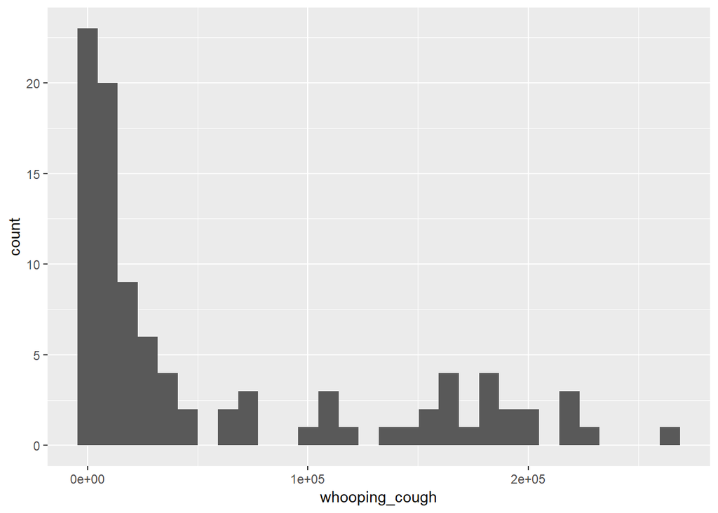

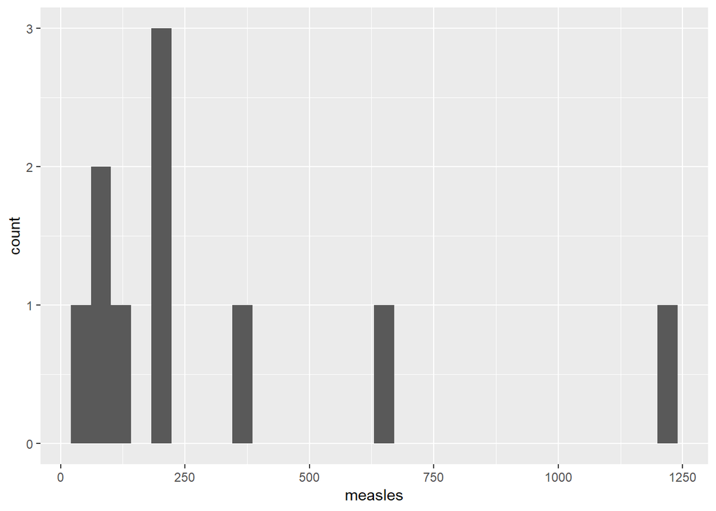

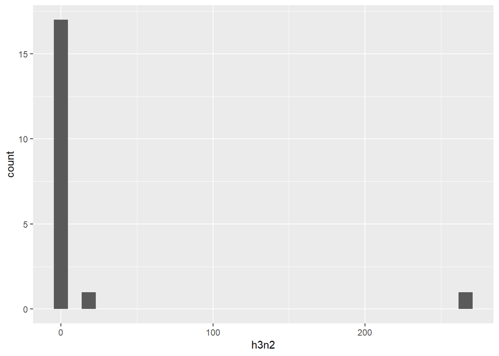

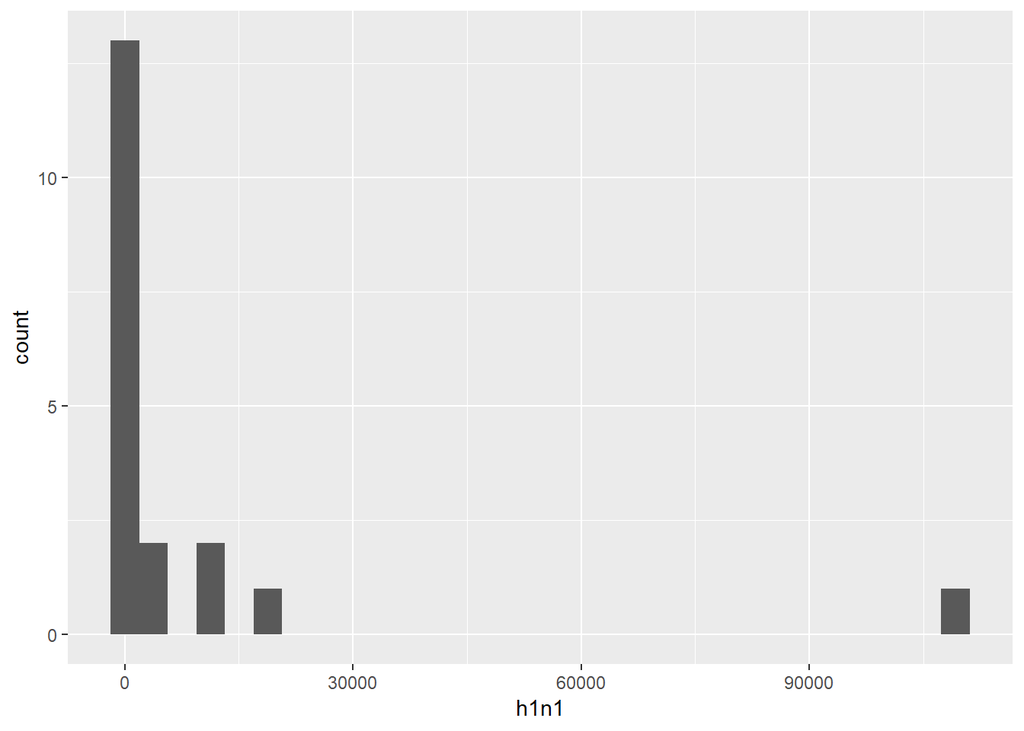

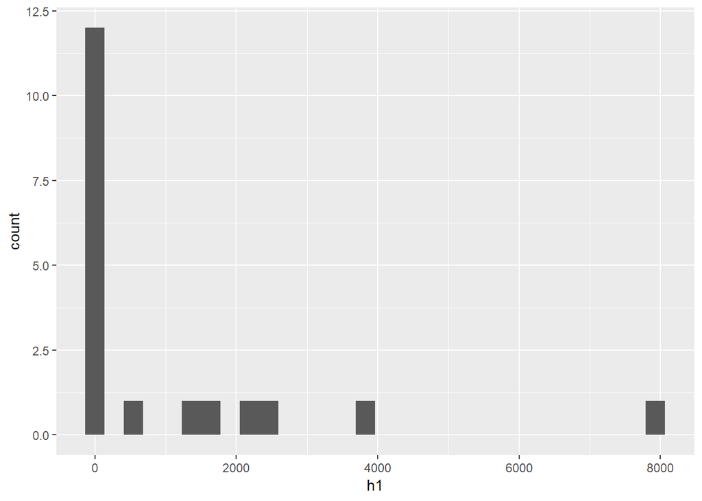

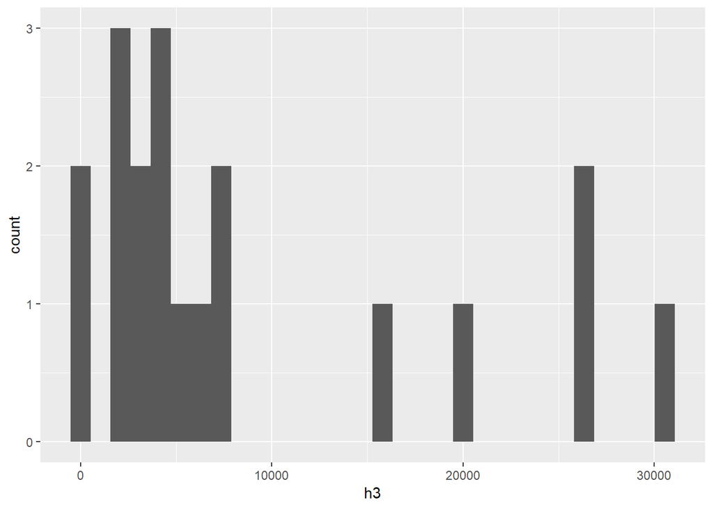

Hmmm, none of the diseases looks to be very normally distributed. Looking at the different histograms, there do appear to be some outliers within the data. However, these outliers of of interest to my analysis, so I will be keeping these points of data in my analysis.

### ScatterPlots

The next thing I want to look at are the different scatterplots. Just as a side note, this is still just the exploration stage, not the visualization stage. These initial visualizations are going to be rough.

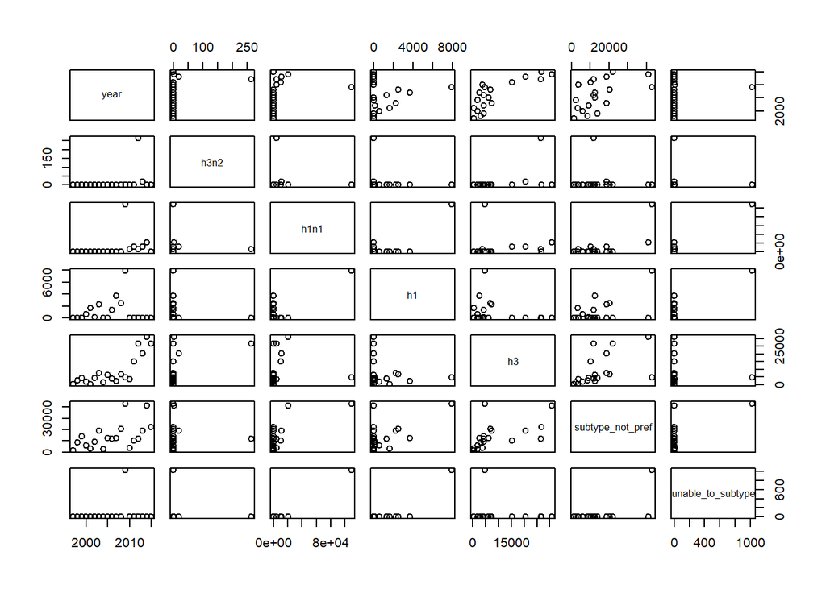

```r
plot(flu_cases_df)
```

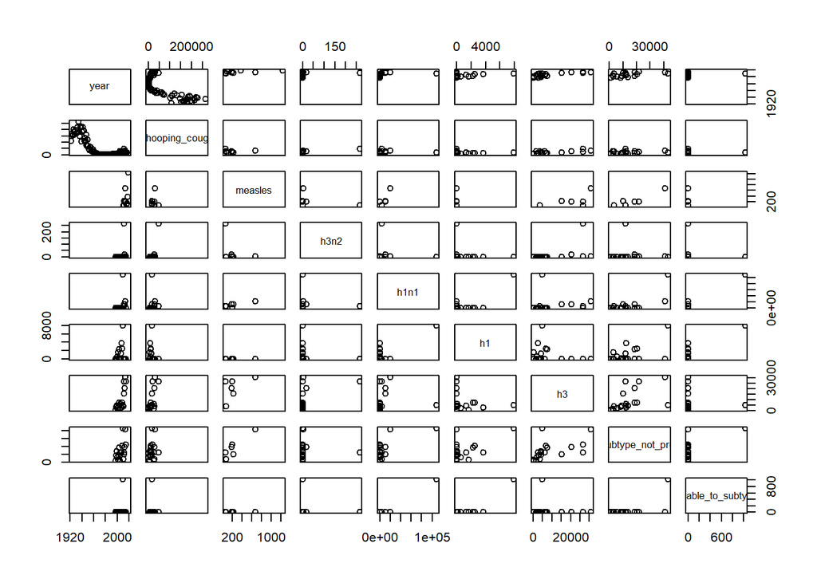

```r
plot(diseases_full)
```

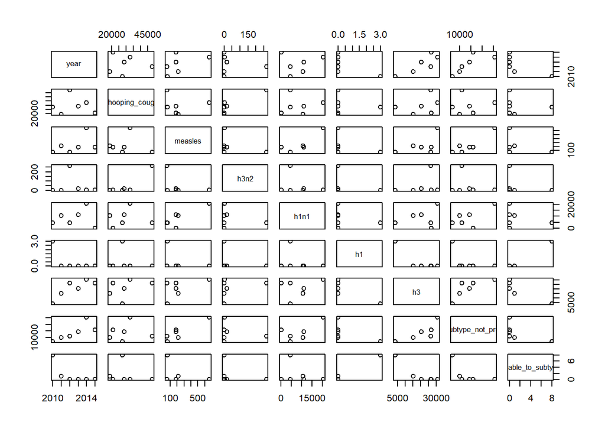

```r
plot(diseases_inner)
```

Hmm, these are interesting to look at. But how about the basic correlations?

```r
# Correlations of the different strains of Flu
cor(flu_cases_df)
```

```
##                         year        h3n2        h1n1          h1
## year              1.00000000  0.28569599  0.26449273  0.06463681
## h3n2              0.28569599  1.00000000 -0.03533948 -0.14029732
## h1n1              0.26449273 -0.03533948  1.00000000  0.77648819
## h1                0.06463681 -0.14029732  0.77648819  1.00000000
## h3                0.79811223  0.46307951  0.05513016 -0.26227493
## subtype_not_pref  0.54594176 -0.03534594  0.70352398  0.53371518
## unable_to_subtype 0.13070637 -0.06105207  0.97528934  0.83552045
##                            h3 subtype_not_pref unable_to_subtype
## year               0.79811223       0.54594176        0.13070637
## h3n2               0.46307951      -0.03534594       -0.06105207
## h1n1               0.05513016       0.70352398        0.97528934
## h1                -0.26227493       0.53371518        0.83552045
## h3                 1.00000000       0.52232484       -0.10458209
## subtype_not_pref   0.52232484       1.00000000        0.60481324
## unable_to_subtype -0.10458209       0.60481324        1.00000000
```

```r
# Correlations of the full join of the different diseases. But we need to deal with the NA values. Let's try to use pairwise.complete.obs
cor(diseases_full, use='pairwise.complete.obs')
```

```
##                          year whooping_cough     measles        h3n2
## year               1.00000000    -0.77712400  0.55219302  0.28569599
## whooping_cough    -0.77712400     1.00000000  0.08227539  0.67893049
## measles            0.55219302     0.08227539  1.00000000 -0.38302728
## h3n2               0.28569599     0.67893049 -0.38302728  1.00000000
## h1n1               0.26449273     0.09635664  0.84685604 -0.03533948
## h1                 0.06463681    -0.22884485 -0.36356216 -0.14029732
## h3                 0.79811223     0.71482100  0.54350205  0.46307951
## subtype_not_pref   0.54594176     0.24782823  0.91343781 -0.03534594
## unable_to_subtype  0.13070637    -0.02402174 -0.37274603 -0.06105207
##                          h1n1          h1          h3 subtype_not_pref
## year               0.26449273  0.06463681  0.79811223       0.54594176
## whooping_cough     0.09635664 -0.22884485  0.71482100       0.24782823
## measles            0.84685604 -0.36356216  0.54350205       0.91343781
## h3n2              -0.03533948 -0.14029732  0.46307951      -0.03534594
## h1n1               1.00000000  0.77648819  0.05513016       0.70352398
## h1                 0.77648819  1.00000000 -0.26227493       0.53371518
## h3                 0.05513016 -0.26227493  1.00000000       0.52232484
## subtype_not_pref   0.70352398  0.53371518  0.52232484       1.00000000
## unable_to_subtype  0.97528934  0.83552045 -0.10458209       0.60481324
##                   unable_to_subtype
## year                     0.13070637
## whooping_cough          -0.02402174
## measles                 -0.37274603
## h3n2                    -0.06105207
## h1n1                     0.97528934
## h1                       0.83552045
## h3                      -0.10458209
## subtype_not_pref         0.60481324
## unable_to_subtype        1.00000000
```

```r
# Correlations of the inner join of the different diseases
cor(diseases_inner)
```

```
##                         year whooping_cough     measles       h3n2
## year               1.0000000    -0.05457420  0.49834263 -0.1164348
## whooping_cough    -0.0545742     1.00000000 -0.07811998  0.8791812
## measles            0.4983426    -0.07811998  1.00000000 -0.3830273
## h3n2              -0.1164348     0.87918124 -0.38302728  1.0000000
## h1n1               0.1073547     0.05676446  0.84685604 -0.2626752
## h1                -0.6546537    -0.08949518 -0.36356216 -0.2206039
## h3                 0.8374523     0.35259229  0.54350205  0.3071935
## subtype_not_pref   0.7813531     0.06455974  0.91343781 -0.2141381
## unable_to_subtype -0.7161695    -0.15437854 -0.37274603 -0.2525582
##                          h1n1          h1         h3 subtype_not_pref
## year               0.10735474 -0.65465367  0.8374523       0.78135308
## whooping_cough     0.05676446 -0.08949518  0.3525923       0.06455974
## measles            0.84685604 -0.36356216  0.5435020       0.91343781
## h3n2              -0.26267525 -0.22060394  0.3071935      -0.21413808
## h1n1               1.00000000 -0.27844481  0.2933812       0.66399747
## h1                -0.27844481  1.00000000 -0.8342551      -0.53442213
## h3                 0.29338122 -0.83425512  1.0000000       0.78495954
## subtype_not_pref   0.66399747 -0.53442213  0.7849595       1.00000000
## unable_to_subtype -0.26505533  0.99220261 -0.8822420      -0.58103347
##                   unable_to_subtype
## year                     -0.7161695
## whooping_cough           -0.1543785
## measles                  -0.3727460
## h3n2                     -0.2525582
## h1n1                     -0.2650553
## h1                        0.9922026
## h3                       -0.8822420
## subtype_not_pref         -0.5810335
## unable_to_subtype         1.0000000
```

Hmmm, there are a lot of interesting things here. But let’s discuss this in a bit in the next section. Before jumping there, let’s actually produce some plots of each disease over the years. Then look at some of how the different disease compare to each other.

#### Diseases by Year

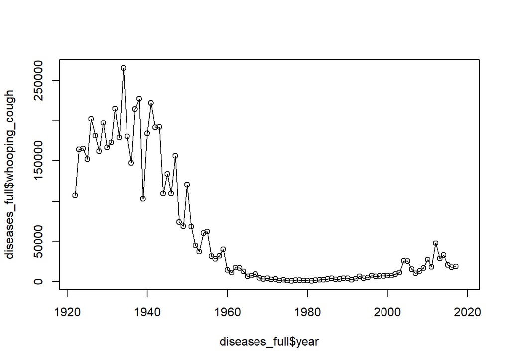

```r
plot(diseases_full$year, diseases_full$whooping_cough, type='o')
```

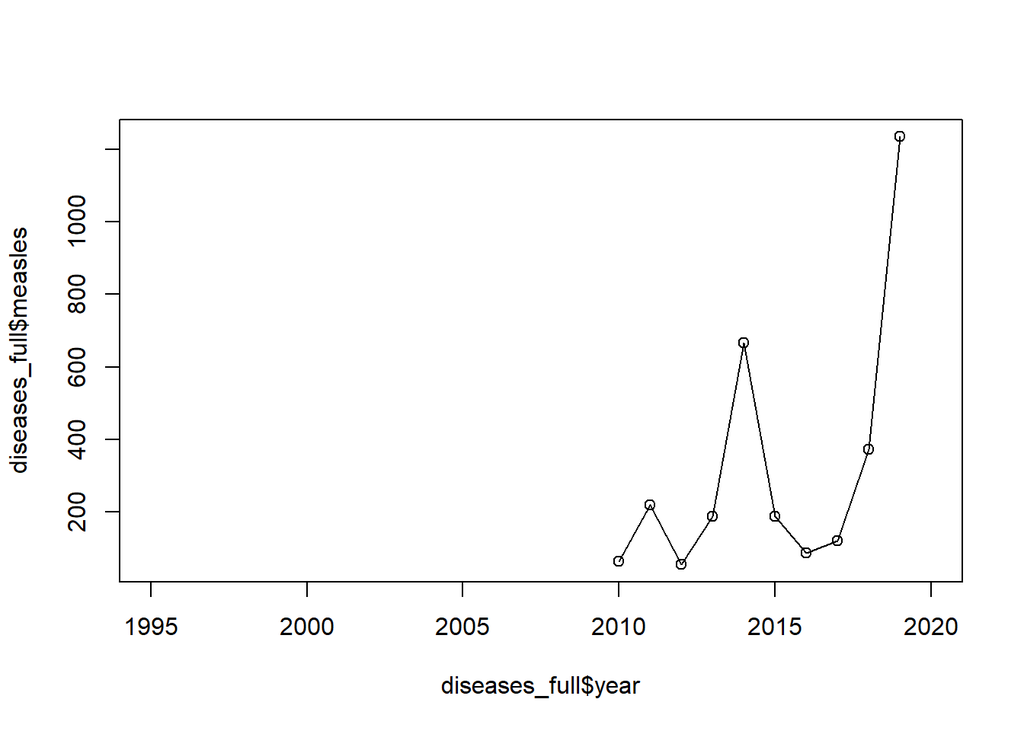

```r
plot(diseases_full$year, diseases_full$measles, type='o', xlim=c(1995,2020))
```

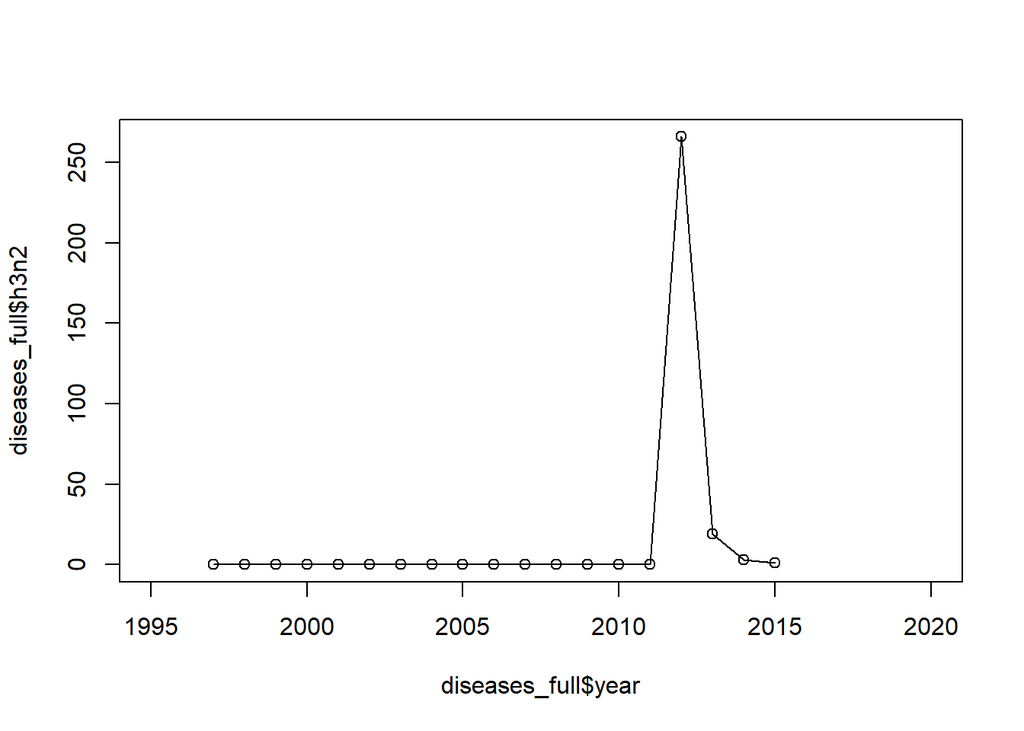

```r
plot(diseases_full$year, diseases_full$h3n2, type='o', xlim=c(1995,2020))
```

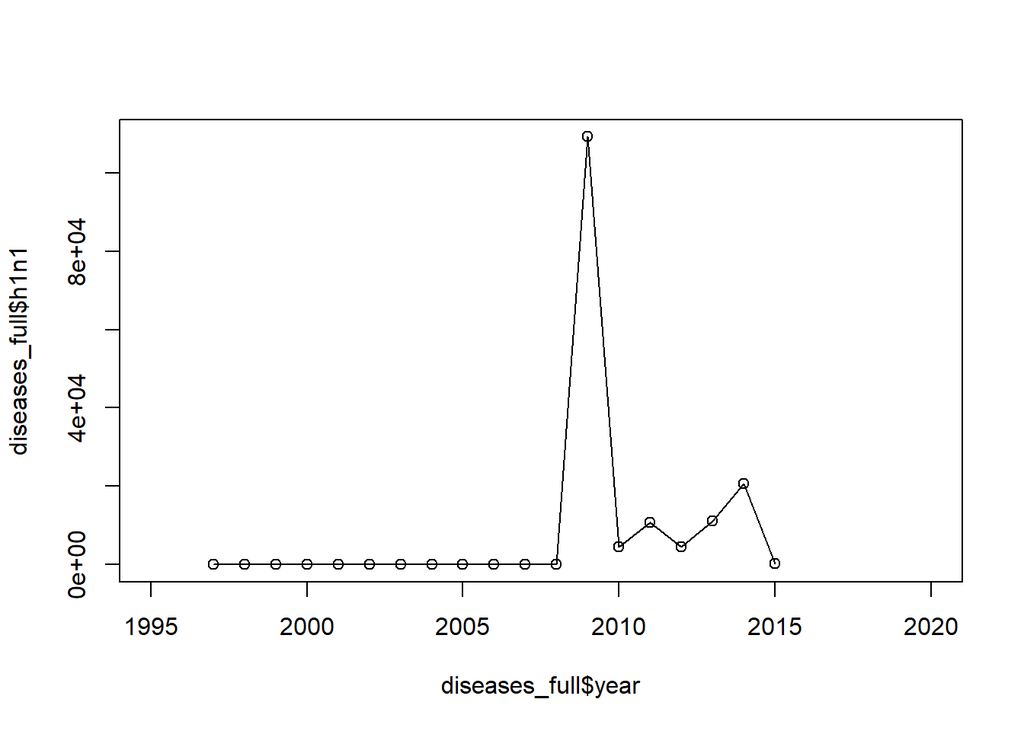

```r
plot(diseases_full$year, diseases_full$h1n1, type='o', xlim=c(1995,2020))
```

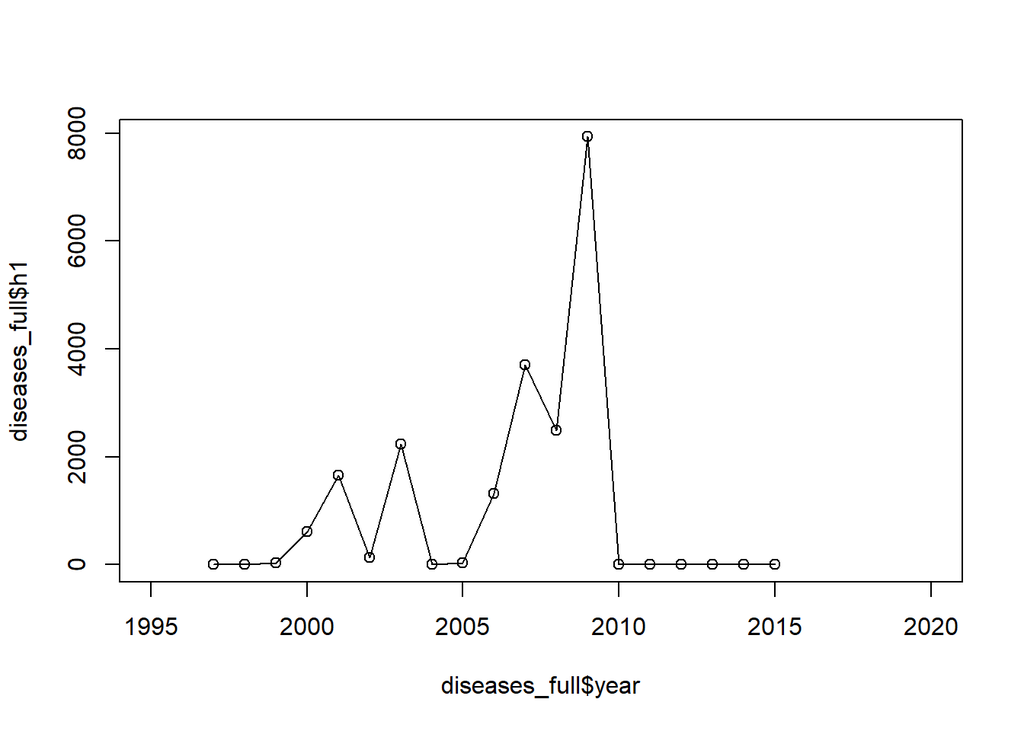

```r
plot(diseases_full$year, diseases_full$h1, type='o', xlim=c(1995,2020))
```

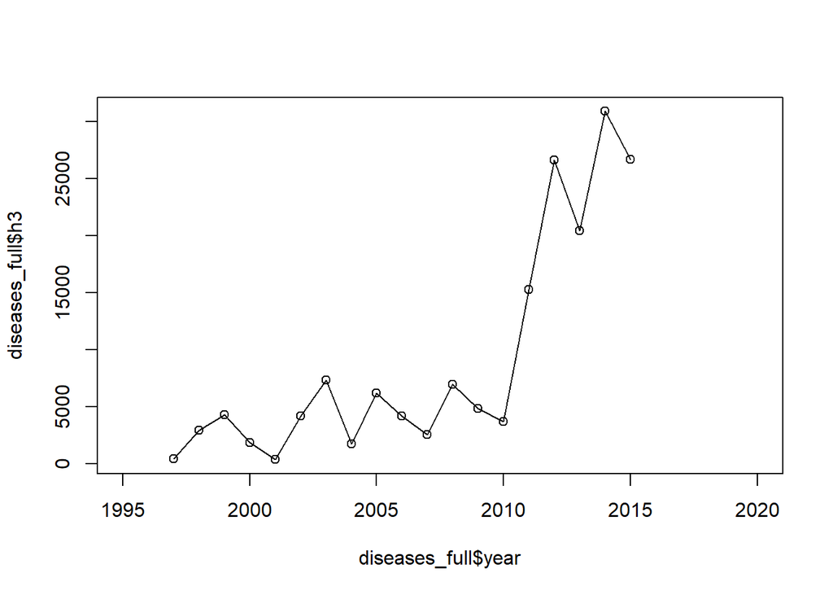

```r
plot(diseases_full$year, diseases_full$h3, type='o', xlim=c(1995,2020))
```

Here we can see that most of these diseases have had an outbreak within the past few years. The H1 strain of the flu has not had many cases over the past few years. Some are still trending up. Looking at these graphs, I’m tempted to say that the h3 strain of the flu or the measles is the most likely to have the next outbreak.

If we were only looking at the number of those infected with each disease, the number of measles would be drowned out by the other diseases. It’s a good thing that these are tracked differently.

#### Measles

I am curious how the number of measles cases look when compared to the other diseases. Let’s take a look at these.

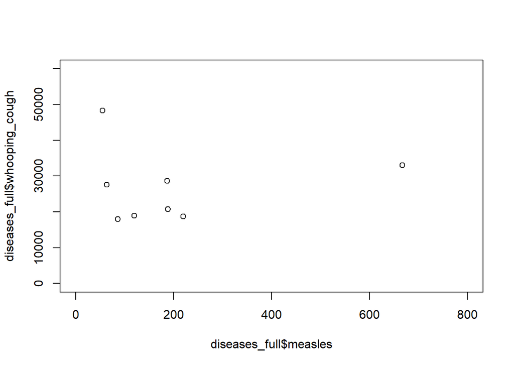

```r
plot(diseases_full$measles, diseases_full$whooping_cough, ylim=c(0,60000), xlim=c(0,800))
```

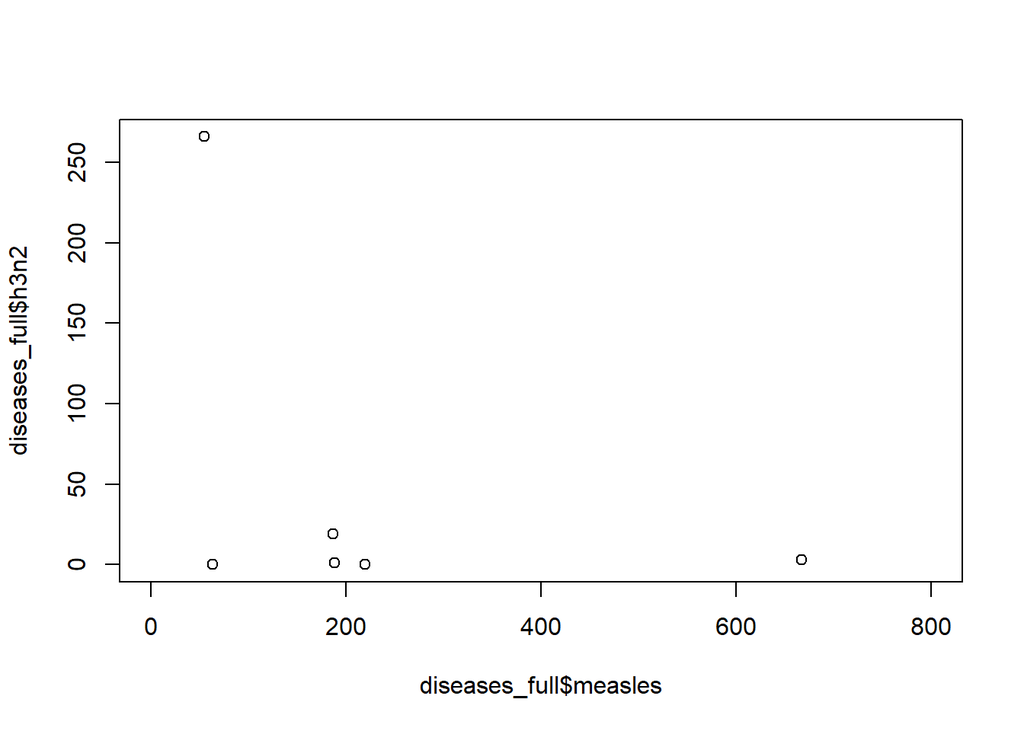

```r
plot(diseases_full$measles, diseases_full$h3n2, xlim=c(0,800))
```

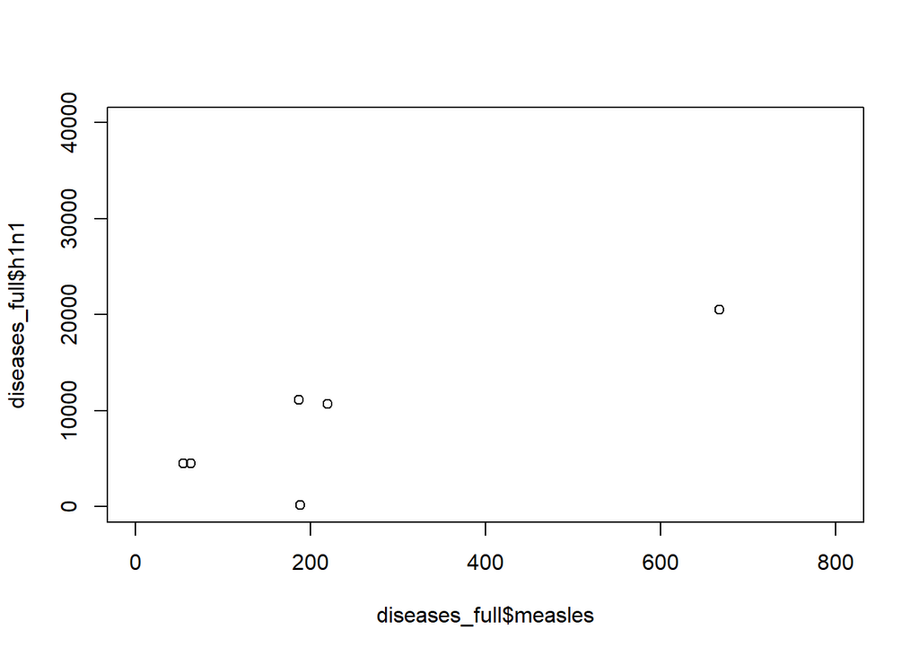

```r
plot(diseases_full$measles, diseases_full$h1n1, ylim=c(0,40000), xlim=c(0,800))
```

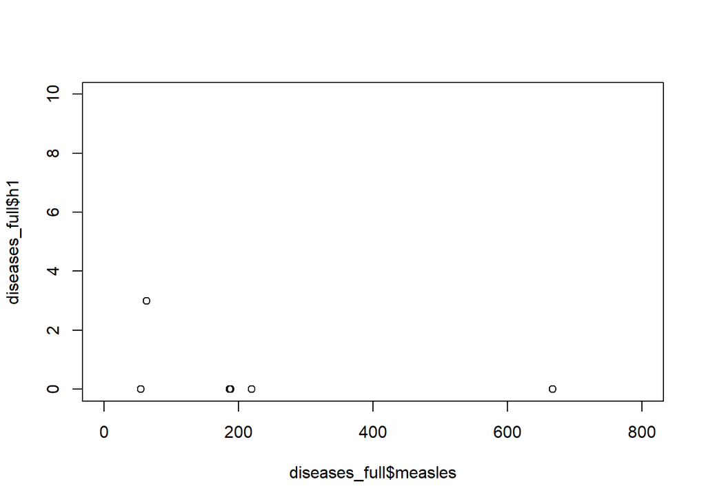

```r
plot(diseases_full$measles, diseases_full$h1, ylim=c(0,10), xlim=c(0,800))
```

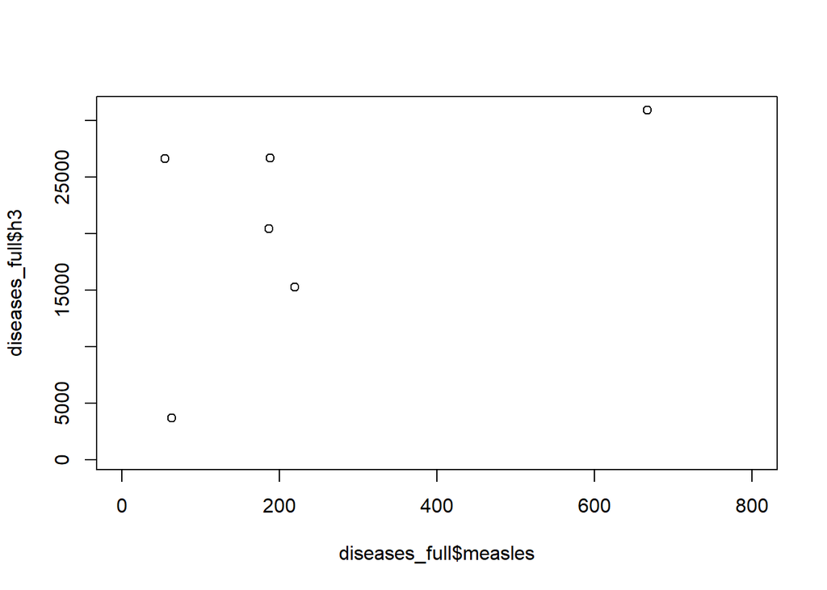

```r
plot(diseases_full$measles, diseases_full$h3, xlim=c(0,800))
```

#### Whoopping Cough

Let’s now take a look at the whooping cough

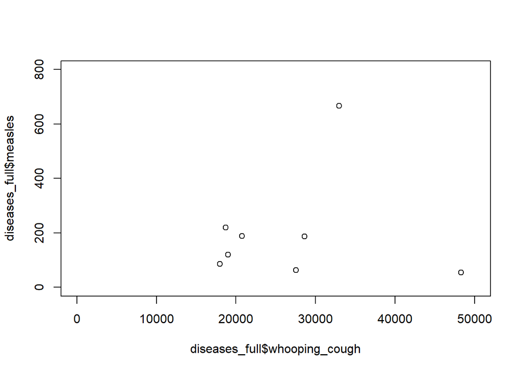

```r
plot(diseases_full$whooping_cough, diseases_full$measles, xlim=c(0,50000), ylim=c(0,800))
```

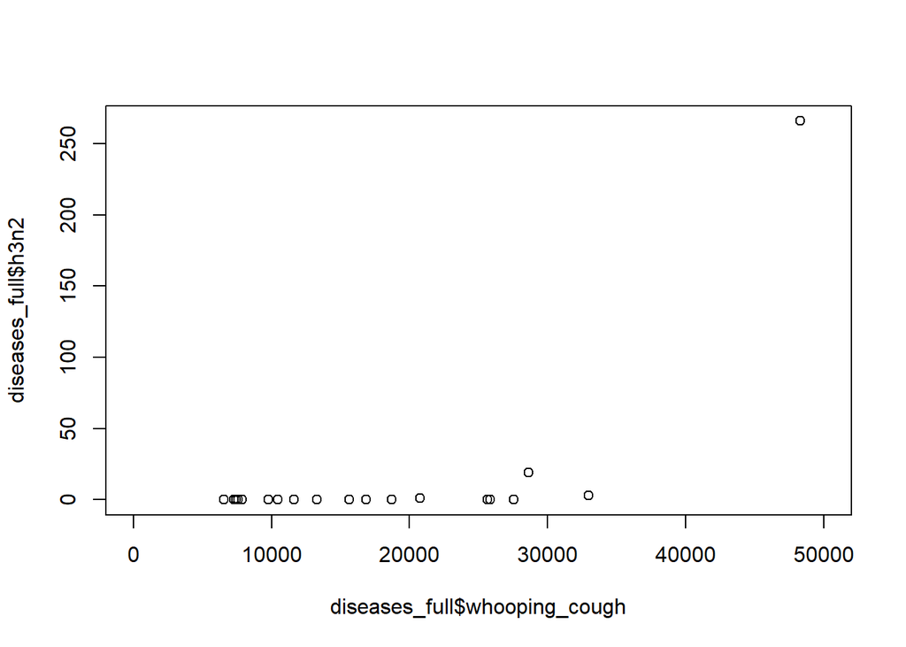

```r
plot(diseases_full$whooping_cough, diseases_full$h3n2, xlim=c(0,50000))
```

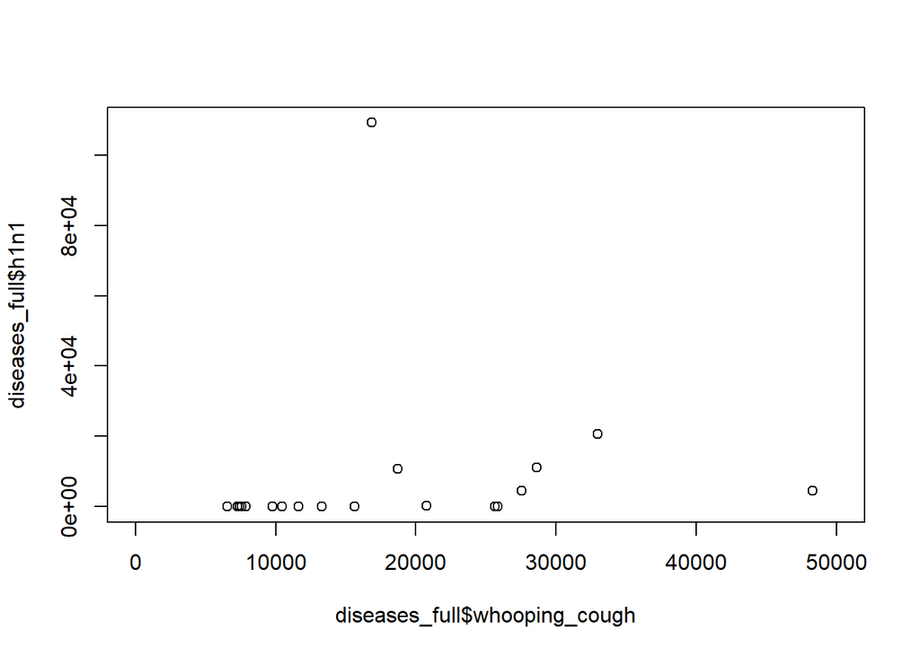

```r
plot(diseases_full$whooping_cough, diseases_full$h1n1, xlim=c(0,50000))
```

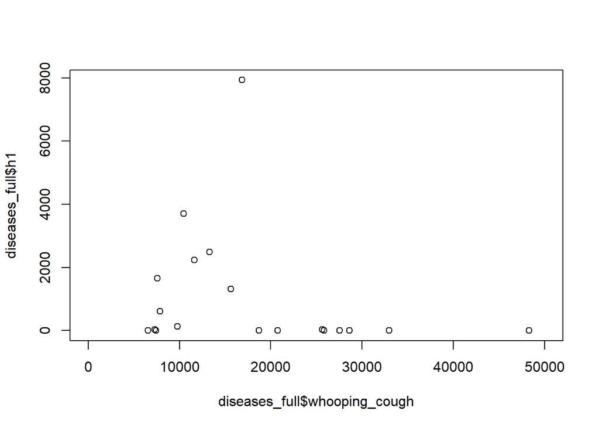

```r
plot(diseases_full$whooping_cough, diseases_full$h1, xlim=c(0,50000))
```

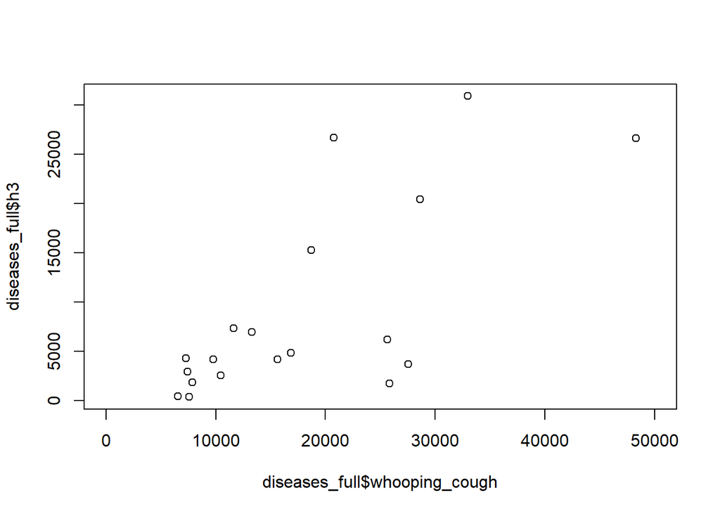

```r
plot(diseases_full$whooping_cough, diseases_full$h3, xlim=c(0,50000))
```

Hmmmm, the whooping cough is positively correlated with the h3n2, h1n1, and h3 strains of the flu, and negatively correlated with the measles and h1 strain of flu. This honeslty surprises me. I thought that the h1 and h1n1 strains would have had similar correlations with the other diseases.

## Correlations

Now that I’ve explored the data, let’s take a look at the correlations between the different diseases. Above, I ran Pearson’s correlation test. However, not all of the variables are normal. That is to say that each of the diseases are skewed right.

This means that Pearson’s Correlation test is not the ideal test to use. Pearson’s correlation test assumes that the data is normally distributed. A better correlation test to use in this case would be Spearman’s Correlation test. When using Spearman’s Correlation test, the data does not need to be normally distributed, but the data must be at least ordinal. Here are the correlation values using Spearman’s test:

```r
cor(diseases_inner, method='spearman')
```

```
##                          year whooping_cough    measles       h3n2
## year               1.00000000      0.1428571  0.4285714  0.4058397
## whooping_cough     0.14285714      1.0000000 -0.3714286  0.8406680
## measles            0.42857143     -0.3714286  1.0000000 -0.3478626
## h3n2               0.40583972      0.8406680 -0.3478626  1.0000000
## h1n1               0.08571429      0.3714286  0.4857143  0.3188741
## h1                -0.65465367     -0.1309307 -0.3927922 -0.5313689
## h3                 0.88571429      0.4285714  0.4285714  0.5217939
## subtype_not_pref   0.94285714      0.3142857  0.5428571  0.4638168
## unable_to_subtype -0.84515425     -0.5408987 -0.1014185 -0.8231932
##                          h1n1         h1         h3 subtype_not_pref
## year               0.08571429 -0.6546537  0.8857143        0.9428571
## whooping_cough     0.37142857 -0.1309307  0.4285714        0.3142857
## measles            0.48571429 -0.3927922  0.4285714        0.5428571
## h3n2               0.31887407 -0.5313689  0.5217939        0.4638168
## h1n1               1.00000000 -0.3927922  0.2571429        0.3714286
## h1                -0.39279220  1.0000000 -0.6546537       -0.6546537
## h3                 0.25714286 -0.6546537  1.0000000        0.9428571
## subtype_not_pref   0.37142857 -0.6546537  0.9428571        1.0000000
## unable_to_subtype -0.27044936  0.7745967 -0.8451543       -0.8451543
##                   unable_to_subtype
## year                     -0.8451543
## whooping_cough           -0.5408987
## measles                  -0.1014185
## h3n2                     -0.8231932
## h1n1                     -0.2704494
## h1                        0.7745967
## h3                       -0.8451543
## subtype_not_pref         -0.8451543
## unable_to_subtype         1.0000000
```

There are a couple of interesting things in these correlations. For one, all of the diseases are positively correlated with the year, except for the h1 strain of the flu. This implies that all of these diseases are becoming more prevalent as time goes on, except for h1 flu.

Something else to note is that the h1 strain of flu is negatively correlated with every other disease that we’ve looked at in this analysis. I was not expecting to see that.

The strongest correlation is between the whooping cough and the h3n2 strain of flu at `0.8406680`.

One last thing is that the number of cases of flu that are not subtyped is also positively correlated with the year, implying that there are more and more cases of the flu that are not classified by strain.

## Covariate Relationships

Let’s start looking at how each of the diseases relate to the year.

### Whooping Cough

```r
reg1 <- lm(whooping_cough ~ year, diseases_full)
summary(reg1)
```

```
##
## Call:
## lm(formula = whooping_cough ~ year, data = diseases_full)
##
## Residuals:
##    Min     1Q Median     3Q    Max
## -66151 -41852  -3672  34833 131280
##
## Coefficients:
##              Estimate Std. Error t value Pr(>|t|)
## (Intercept) 4171742.2   343493.5   12.14   <2e-16 ***
## year          -2087.8      174.4  -11.97   <2e-16 ***
## ---
## Signif. codes:  0 '***' 0.001 '**' 0.01 '*' 0.05 '.' 0.1 ' ' 1
##
## Residual standard error: 47350 on 94 degrees of freedom
##   (2 observations deleted due to missingness)
## Multiple R-squared:  0.6039, Adjusted R-squared:  0.5997
## F-statistic: 143.3 on 1 and 94 DF,  p-value: < 2.2e-16
```

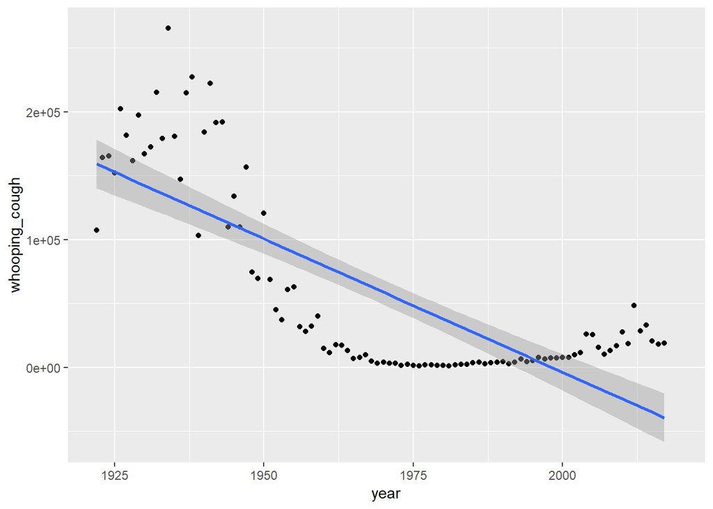

```r
ggplot(diseases_full, aes(x=year, y=whooping_cough)) + geom_point() + geom_smooth(method='lm')
```

Hmmm, this is the analysis from 1925 on, but what about more recently?

```r
d2000 <- filter(diseases_full, year >= 2000)
reg1 <- lm(whooping_cough ~ year, d2000)
summary(reg1)
```

```
##
## Call:
## lm(formula = whooping_cough ~ year, data = d2000)
##
## Residuals:
##    Min     1Q Median     3Q    Max
##  -9501  -5467  -3518   5644  24839
##
## Coefficients:
##               Estimate Std. Error t value Pr(>|t|)
## (Intercept) -2003929.6   829249.6  -2.417   0.0280 *
## year            1007.6      412.9   2.441   0.0267 *
## ---
## Signif. codes:  0 '***' 0.001 '**' 0.01 '*' 0.05 '.' 0.1 ' ' 1
##
## Residual standard error: 9088 on 16 degrees of freedom
##   (2 observations deleted due to missingness)
## Multiple R-squared:  0.2713, Adjusted R-squared:  0.2257
## F-statistic: 5.956 on 1 and 16 DF,  p-value: 0.02667
```

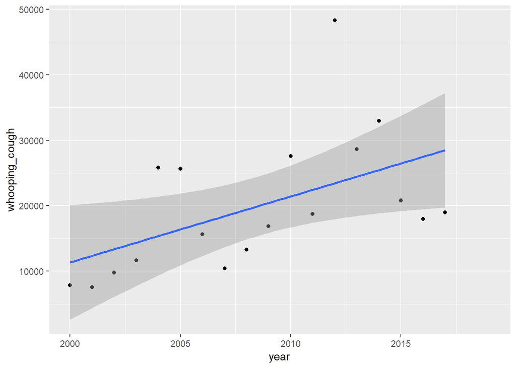

```r
ggplot(d2000, aes(x=year, y=whooping_cough)) + geom_point() + geom_smooth(method='lm')
```

Hmmm, interesting. Fromm 2000 - 2017, the number of cases of whooping cough have been increasing. Overall, since the vaccine for the whooping cough was developed, the number of cases each year has dropped dramatically, but it is on the rise again.

### Measles

```r
reg1 <- lm(measles ~ year, diseases_full)
summary(reg1)
```

```
##
## Call:
## lm(formula = measles ~ year, data = diseases_full)
##
## Residuals:
##    Min     1Q Median     3Q    Max
## -368.1 -179.0  -63.1  114.9  610.8
##
## Coefficients:
##               Estimate Std. Error t value Pr(>|t|)
## (Intercept) -135763.33   72641.57  -1.869   0.0986 .
## year             67.55      36.06   1.873   0.0979 .
## ---
## Signif. codes:  0 '***' 0.001 '**' 0.01 '*' 0.05 '.' 0.1 ' ' 1
##
## Residual standard error: 327.5 on 8 degrees of freedom
##   (88 observations deleted due to missingness)
## Multiple R-squared:  0.3049, Adjusted R-squared:  0.218
## F-statistic: 3.509 on 1 and 8 DF,  p-value: 0.0979
```

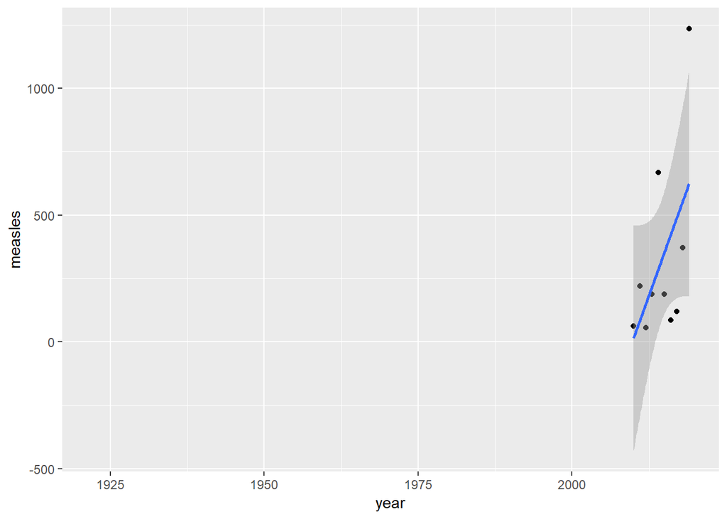

```r
ggplot(diseases_full, aes(x=year, y=measles)) + geom_point() + geom_smooth(method='lm')
```

This gives us a squashed view, so let’s expand that out.

```r
reg1 <- lm(measles ~ year, d2000)
summary(reg1)
```

```
##
## Call:
## lm(formula = measles ~ year, data = d2000)
##
## Residuals:
##    Min     1Q Median     3Q    Max
## -368.1 -179.0  -63.1  114.9  610.8
##
## Coefficients:
##               Estimate Std. Error t value Pr(>|t|)
## (Intercept) -135763.33   72641.57  -1.869   0.0986 .
## year             67.55      36.06   1.873   0.0979 .
## ---
## Signif. codes:  0 '***' 0.001 '**' 0.01 '*' 0.05 '.' 0.1 ' ' 1
##
## Residual standard error: 327.5 on 8 degrees of freedom
##   (10 observations deleted due to missingness)
## Multiple R-squared:  0.3049, Adjusted R-squared:  0.218
## F-statistic: 3.509 on 1 and 8 DF,  p-value: 0.0979
```

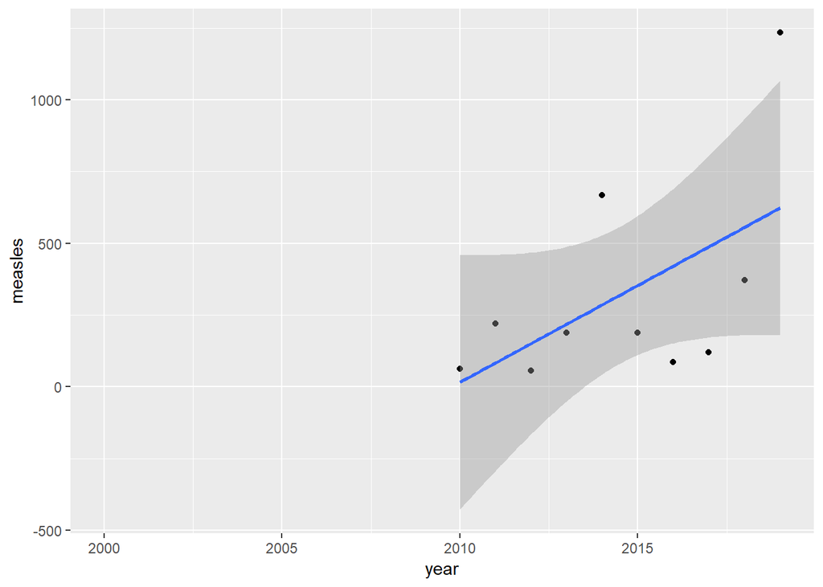

```r
ggplot(d2000, aes(x=year, y=measles)) + geom_point() + geom_smooth(method='lm')
```

Hmmm, the interesting thing here is that the regression line is not statistically significant. The p-value 0.0979. However, it can still be seen that the number of cases is increasing.

### h3n2 Strain of Flu

```r
reg1 <- lm(h3n2 ~ year, diseases_full)
summary(reg1)
```

```
##
## Call:
## lm(formula = h3n2 ~ year, data = diseases_full)
##
## Residuals:
##     Min      1Q  Median      3Q     Max
## -42.032 -22.939 -12.119   1.791 232.242
##
## Coefficients:
##              Estimate Std. Error t value Pr(>|t|)
## (Intercept) -6185.793   5044.820  -1.226    0.237
## year            3.091      2.515   1.229    0.236
##
## Residual standard error: 60.04 on 17 degrees of freedom
##   (79 observations deleted due to missingness)
## Multiple R-squared:  0.08162,    Adjusted R-squared:  0.0276
## F-statistic: 1.511 on 1 and 17 DF,  p-value: 0.2357
```

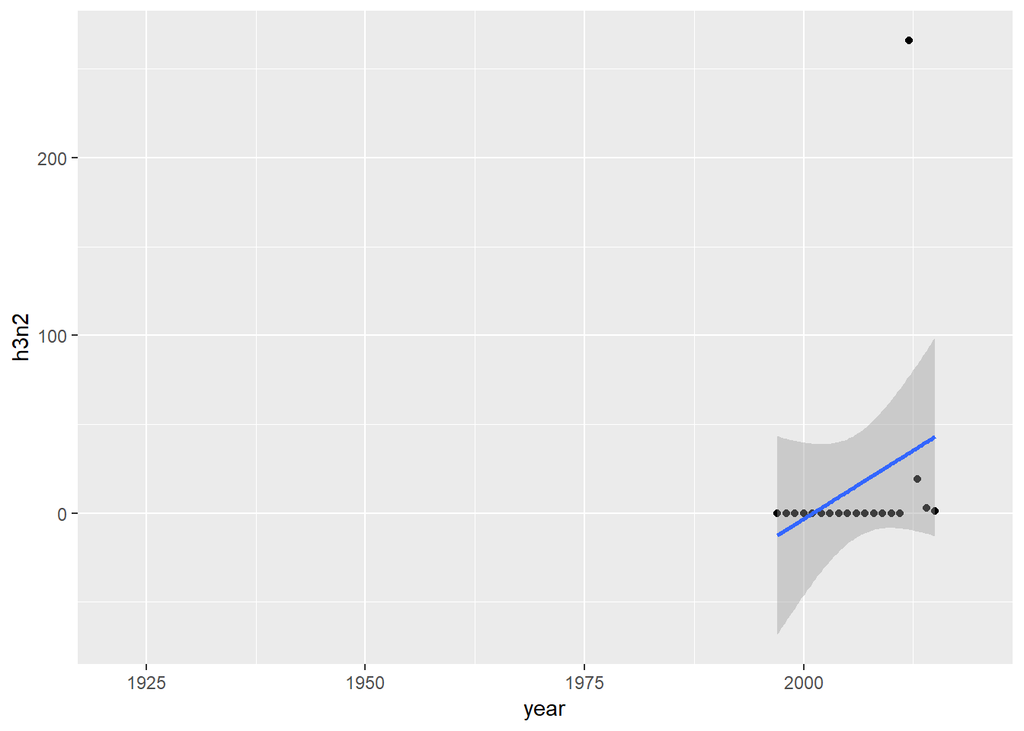

```r
ggplot(diseases_full, aes(x=year, y=h3n2)) + geom_point() + geom_smooth(method='lm')
```

Once again, let’s focus in on what data we do have for h3n2.

```r
reg1 <- lm(h3n2 ~ year, d2000)
summary(reg1)
```

```
##
## Call:
## lm(formula = h3n2 ~ year, data = d2000)
##
## Residuals:
##     Min      1Q  Median      3Q     Max
## -46.368 -24.900 -14.155   0.497 230.354
##
## Coefficients:
##              Estimate Std. Error t value Pr(>|t|)
## (Intercept) -7825.949   7169.764  -1.092    0.293
## year            3.907      3.571   1.094    0.292
##
## Residual standard error: 65.85 on 14 degrees of freedom
##   (4 observations deleted due to missingness)
## Multiple R-squared:  0.07876,    Adjusted R-squared:  0.01296
## F-statistic: 1.197 on 1 and 14 DF,  p-value: 0.2924
```

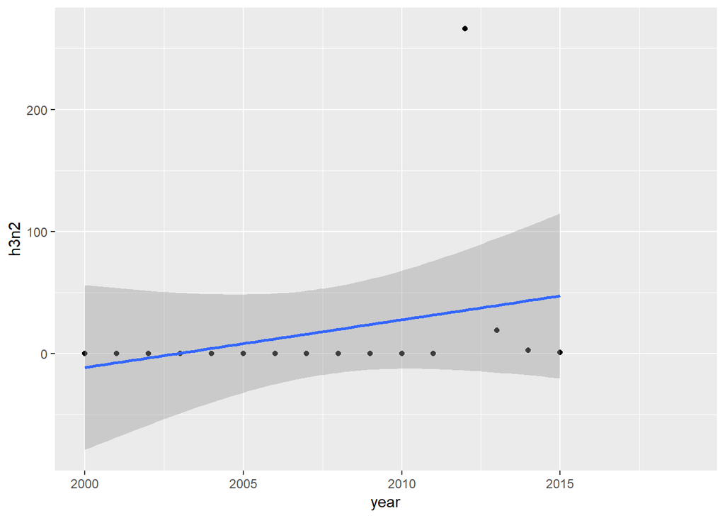

```r
ggplot(d2000, aes(x=year, y=h3n2)) + geom_point() + geom_smooth(method='lm')
```

This is another disease that is not statistically significat (p-value = 0.2924). Having said that, this disease had an outbreak in 2012 after having 12 years of no cases. There was a single case reported in 2015, so the disease is tappering off again. The projected increase is not significant without more data.